# PCA_gen function and figure

Trevor Faske

This Rmarkdown goes through the created PCA function that makes a PCA for genetic data. It can handle a 012, gprob, or pntest entropy file. By default, function uses standardizes by rate proportional to expectation of genetic drift following Patterson et al 2006.

### Loading packages

```r
library(data.table) #fread
library(ggplot2)
library(ggsci) #colors discrete
library('wesanderson') #colors continuous
library(patchwork) #multipanel figues
```

## Function for PCA_gen

PCA for genetic data (012 or gprob file)

#### input files:

- **g:** genotypic data with individuals as rows and snps as coloumns. Can include missing data. Either genotype probabilities or 012 format
- **indv:** dataframe with rows corresponding to individuals in df_gen file. Must have Pop and ID column
- **method:** (default = patterson)
  - **patterson:** standardization by rate proportional to expectation of genetic drift (denominator = sqrt(af*(1-af))) (Patterson et al. 2006)
  - **none:** no center or no standardization
  - **center:** centering only, no standardization
  - **stand:** center and standardizing
- **num:** number of PC axes to keep (default <= 5)

##### output files:

- **pca_df:** dataframe with rows as individuals and columns as PC1-num. Will have contents of indv_file if provided.
- **pve:** list of proportion of variance explained for each PC

```r
############# PCA_gen function ######################

PCA_gen <- function(g,indv_file=NULL,method='patterson',num=5){

  ## make g a matrix
  g <- as.matrix(g)

  #remove any NA (only if 012) and make numeric
  g <- apply(g, 2, function(d) gsub(-1,NA,d,fixed=TRUE))
  g <- apply(g, 2, function(d) as.numeric(d))

  ## run method and PCA
  if(method == 'patterson'){

    #center and standardize by drift
    colmean<-apply(g,2,mean,na.rm=TRUE)
    normalize<-matrix(nrow = nrow(g),ncol=ncol(g))
    af<-colmean/2
    for (m in 1:length(af)){
      nr<-g[ ,m]-colmean[m]
      dn<-sqrt(af[m]*(1-af[m]))
      normalize[ ,m]<-nr/dn
    }

    #if NA, make equal to the mean (which is 0)
    normalize[is.na(normalize)]<-0

    pca_out <- prcomp(normalize,scale. = FALSE,center=FALSE)
    pve <- summary(pca_out)$importance[2,1:5]

  }else if(method == 'none'){

    pca_out <- prcomp(g,scale. = FALSE,center=FALSE)
    pve <- summary(pca_out)$importance[2,1:5]

  }else if(method == 'center'){

    #center
    g_c <- apply(g,2,function(d) (d-mean(d,na.rm=TRUE)))

    pca_out <- prcomp(g_c,scale. = FALSE,center=FALSE)
    pve <- summary(pca_out)$importance[2,1:5]

  }else if(method == 'stand'){

    #center and standardize
    g_z <- apply(g,2,function(d) (d-mean(d,na.rm=TRUE))/sd(d,na.rm=TRUE))

    pca_out <- prcomp(g_z,scale. = FALSE,center=FALSE)
    pve <- summary(pca_out)$importance[2,1:5]

  }else{
    stop('method not correct')
  }

  ## select number of PC axes to use
  if(nrow(g) < num){
    num <- nrow(g)
  }
  pca_df <- pca_out$x[,1:num]

  ## Add indv_file if available
  if (!(is.null(indv_file))){
    pca_df <- cbind(pca_df,indv_file)
  }

  return(list("pca_df"=pca_df,'pve'=pve))
}
```

#### input files:

- **pca_df:** data frame including PC scores and information for each individual
- **pve:** percent variance explained for each PC axis
- **axes:** two axes for x- and y-axis of the figure (default = c(1,2))
- **group:** data frame column to color points by (default = ‘Pop’)
- **colors:** vector of colors for points (default = NULL, defers to color_choose)
- **legend:** where to put legend, for options see ggplot *legend.position* (default = ‘none’)
- **legend.title:** legend title (default = NULL)

```r
####################### PCA_fig function ##################################

PCA_fig <- function(pca_df,pve,axes=c(1,2),group='Pop',colors=NULL,legend='none',legend.title=NULL){

  ## specify colors
  if (is.null(colors)){
    col <- color_choose(length(unique(pca_df[[group]])))
  }else{
    col <- colors
  }

  ## PC axis labels
  PCx <- paste0('PC',axes[1])
  PCy <- paste0('PC',axes[2])
  xlab <- paste0(PCx,' (',round(pve[axes[1]]*100,2),'%)')
  ylab <- paste0(PCy,' (',round(pve[axes[2]]*100,2),'%)')
  pca_plot <- ggplot(data = pca_df, aes(x=.data[[PCx]],
                                        y=.data[[PCy]],
                                        fill=.data[[group]],)) +
    geom_point(colour='black',pch=21,size = 4) +
    scale_fill_manual(name=legend.title,values=col) +
    xlab(xlab) + ylab(ylab) +
    theme_bw() +
    theme(legend.position = legend,
      axis.text = element_text(size=13),
      axis.title = element_text(size = 16, colour="black",face = "bold",vjust = 1),
      plot.title = element_text(size = 16, colour="black",face = "bold"),
      panel.border = element_rect(linewidth = 1.5, colour = "black"),
      legend.text = element_text(size=13),
      legend.title = element_text(size = 16, colour="black",face = "bold",vjust = 1),
      panel.grid.major = element_blank(),
      panel.grid.minor = element_blank())
  #print(pca_plot)
  return(pca_plot)
}

## choose colors for PCA
color_choose <- function(num){
  col10 <- pal_npg()(10)
  col20 <- pal_d3(palette = 'category20')(20)
  if (num <= 10){
    col_out <- col10[1:num]
  }else if (num <= 20){
    col_out <- col20[1:num]
  }else{
    col_out <- hue_pal()(num)
  }
  return(col_out)
}
```

### Run PCA

using rabbitbrush (Faske et al., 2021 Evol. App.) as example. note: fread is FAST.

```r
df012<-fread("good_snps.recode.vcf.012",sep="\t", data.table=F)
df012 <- df012[,-1]

Pop_ID <- read.csv('Pop_ID.csv')

pca_out <- PCA_gen(df012,Pop_ID)
pve <- pca_out$pve[1:5]

pca_df <- pca_out$pca_df[,1:5]
pca_df <- cbind(Pop_ID,pca_df)
```

### Plot PCA

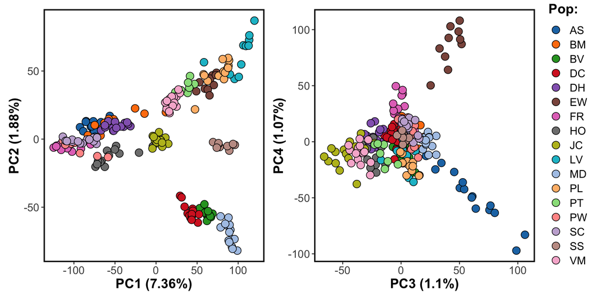

```r
pca12_plot <- PCA_fig(pca_df,pve)
pca34_plot <- PCA_fig(pca_df,pve,axes=c(3,4),legend = 'right',legend.title = 'Pop:')

pca12_plot + pca34_plot
```